# Risk Factor Analysis

## Outcome Variable

**Outcome Variable:** pers_wasted624

## Predictor Variables

**Intervention Variable:** ever_wasted06

**Adjustment Set:**

- sex
- arm
- brthmon
- vagbrth
- single
- W_mage
- W_mhtcm
- W_mwtkg
- W_mbmi
- W_meducyrs
- W_feducyrs
- W_parity
- delta_brthmon
- delta_vagbrth
- delta_single
- delta_W_mage
- delta_W_mhtcm
- delta_W_mwtkg
- delta_W_mbmi
- delta_W_meducyrs
- delta_W_feducyrs
- delta_W_parity

## Stratifying Variables

The analysis was stratified on these variable(s):

- studyid
- country

## Data Summary

| studyid | country | ever_wasted06 | pers_wasted624 | n_cell | n | outcome_variable |
| --- | --- | --- | --- | --- | --- | --- |
| CMC-V-BCS-2002 | INDIA | 0 | 0 | 175 | 370 | pers_wasted624 |
| CMC-V-BCS-2002 | INDIA | 0 | 1 | 3 | 370 | pers_wasted624 |
| CMC-V-BCS-2002 | INDIA | 1 | 0 | 167 | 370 | pers_wasted624 |
| CMC-V-BCS-2002 | INDIA | 1 | 1 | 25 | 370 | pers_wasted624 |
| CMIN | BANGLADESH | 0 | 0 | 196 | 252 | pers_wasted624 |
| CMIN | BANGLADESH | 0 | 1 | 11 | 252 | pers_wasted624 |
| CMIN | BANGLADESH | 1 | 0 | 31 | 252 | pers_wasted624 |
| CMIN | BANGLADESH | 1 | 1 | 14 | 252 | pers_wasted624 |
| COHORTS | GUATEMALA | 0 | 0 | 786 | 1017 | pers_wasted624 |
| COHORTS | GUATEMALA | 0 | 1 | 25 | 1017 | pers_wasted624 |
| COHORTS | GUATEMALA | 1 | 0 | 190 | 1017 | pers_wasted624 |
| COHORTS | GUATEMALA | 1 | 1 | 16 | 1017 | pers_wasted624 |
| COHORTS | INDIA | 0 | 0 | 4756 | 6892 | pers_wasted624 |
| COHORTS | INDIA | 0 | 1 | 113 | 6892 | pers_wasted624 |
| COHORTS | INDIA | 1 | 0 | 1366 | 6892 | pers_wasted624 |
| COHORTS | INDIA | 1 | 1 | 657 | 6892 | pers_wasted624 |
| COHORTS | PHILIPPINES | 0 | 0 | 2013 | 2808 | pers_wasted624 |
| COHORTS | PHILIPPINES | 0 | 1 | 98 | 2808 | pers_wasted624 |
| COHORTS | PHILIPPINES | 1 | 0 | 569 | 2808 | pers_wasted624 |
| COHORTS | PHILIPPINES | 1 | 1 | 128 | 2808 | pers_wasted624 |
| CONTENT | PERU | 0 | 0 | 211 | 215 | pers_wasted624 |
| CONTENT | PERU | 0 | 1 | 0 | 215 | pers_wasted624 |
| CONTENT | PERU | 1 | 0 | 4 | 215 | pers_wasted624 |
| CONTENT | PERU | 1 | 1 | 0 | 215 | pers_wasted624 |
| EE | PAKISTAN | 0 | 0 | 234 | 374 | pers_wasted624 |
| EE | PAKISTAN | 0 | 1 | 12 | 374 | pers_wasted624 |
| EE | PAKISTAN | 1 | 0 | 91 | 374 | pers_wasted624 |
| EE | PAKISTAN | 1 | 1 | 37 | 374 | pers_wasted624 |
| GMS-Nepal | NEPAL | 0 | 0 | 319 | 590 | pers_wasted624 |
| GMS-Nepal | NEPAL | 0 | 1 | 34 | 590 | pers_wasted624 |

[output cut: 90 more lines]

The following strata were considered:

- studyid: CMC-V-BCS-2002, country: INDIA
- studyid: CMIN, country: BANGLADESH
- studyid: COHORTS, country: GUATEMALA
- studyid: COHORTS, country: INDIA
- studyid: COHORTS, country: PHILIPPINES
- studyid: CONTENT, country: PERU
- studyid: EE, country: PAKISTAN
- studyid: GMS-Nepal, country: NEPAL
- studyid: Guatemala BSC, country: GUATEMALA
- studyid: IRC, country: INDIA
- studyid: JiVitA-3, country: BANGLADESH
- studyid: JiVitA-4, country: BANGLADESH
- studyid: Keneba, country: GAMBIA
- studyid: LCNI-5, country: MALAWI
- studyid: MAL-ED, country: BANGLADESH
- studyid: MAL-ED, country: BRAZIL
- studyid: MAL-ED, country: INDIA
- studyid: MAL-ED, country: NEPAL
- studyid: MAL-ED, country: PERU
- studyid: MAL-ED, country: SOUTH AFRICA
- studyid: MAL-ED, country: TANZANIA, UNITED REPUBLIC OF
- studyid: NIH-Birth, country: BANGLADESH
- studyid: NIH-Crypto, country: BANGLADESH
- studyid: PROBIT, country: BELARUS
- studyid: PROVIDE, country: BANGLADESH
- studyid: ResPak, country: PAKISTAN
- studyid: SAS-CompFeed, country: INDIA
- studyid: SAS-FoodSuppl, country: INDIA
- studyid: TanzaniaChild2, country: TANZANIA, UNITED REPUBLIC OF
- studyid: ZVITAMBO, country: ZIMBABWE

### Dropped Strata

Some strata were dropped due to rare outcomes:

- studyid: CMC-V-BCS-2002, country: INDIA
- studyid: CONTENT, country: PERU
- studyid: Guatemala BSC, country: GUATEMALA
- studyid: MAL-ED, country: BANGLADESH
- studyid: MAL-ED, country: BRAZIL
- studyid: MAL-ED, country: NEPAL
- studyid: MAL-ED, country: PERU
- studyid: MAL-ED, country: SOUTH AFRICA
- studyid: MAL-ED, country: TANZANIA, UNITED REPUBLIC OF
- studyid: PROBIT, country: BELARUS

## Methods Detail

We’re interested in the causal parameters $E[Y_a]$ for all values of $a \in \mathcal{A}$. These parameters represent the mean outcome if, possibly contrary to fact, we intervened to set all units to have $A=a$. Under the randomization and positivity assumptions, these are identified by the statistical parameters $\psi_a=E_W[E_{Y|A,W}(Y|A=a,W)]$. In addition, we’re interested in the mean of $Y$, $E[Y]$ under no intervention (the observed mean). We will estimate these parameters by using SuperLearner to fit the relevant likelihood factors – $E_{Y|A,W}(Y|A=a,W)$ and $p(A=a|W)$, and then updating our likelihood fit using a joint TMLE.

For unadjusted analyses ($W=\{\}$), initial likelihoods were estimated using Lrnr_glm to estimate the simple $E(Y|A)$ and Lrnr_mean to estimate $p(A)$. For adjusted analyses, a small library containing Lrnr_glmnet, Lrnr_xgboost, and Lrnr_mean was used.

Having estimated these parameters, we will then use the delta method to estimate relative risks and attributable risks relative to a prespecified baseline level of $A$.

[output not shown]

[output not shown]

[output not shown]

[output not shown]

# Results Detail

## Results Plots

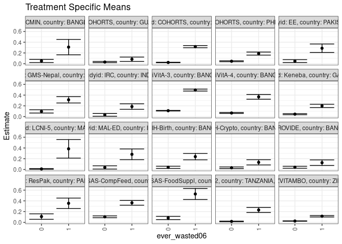

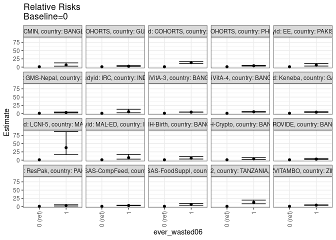

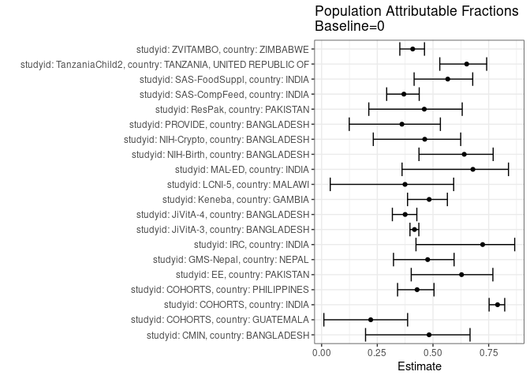

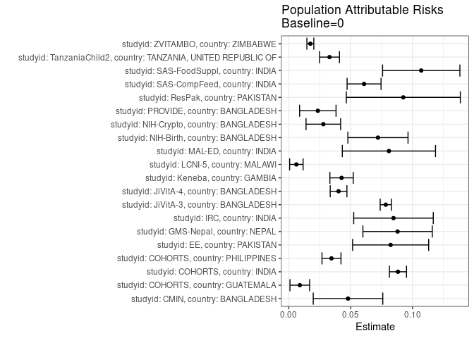

## Results Table

### Parameter: TSM

| studyid | country | intervention_level | baseline_level | estimate | ci_lower | ci_upper |
| --- | --- | --- | --- | --- | --- | --- |
| CMIN | BANGLADESH | 0 | NA | 0.0513402 | 0.0211271 | 0.0815532 |
| CMIN | BANGLADESH | 1 | NA | 0.3089686 | 0.1658891 | 0.4520482 |
| COHORTS | GUATEMALA | 0 | NA | 0.0314258 | 0.0193372 | 0.0435144 |
| COHORTS | GUATEMALA | 1 | NA | 0.0833844 | 0.0433602 | 0.1234087 |
| COHORTS | INDIA | 0 | NA | 0.0234702 | 0.0192078 | 0.0277326 |
| COHORTS | INDIA | 1 | NA | 0.3173732 | 0.2972645 | 0.3374818 |
| COHORTS | PHILIPPINES | 0 | NA | 0.0459874 | 0.0370646 | 0.0549102 |
| COHORTS | PHILIPPINES | 1 | NA | 0.1885081 | 0.1600596 | 0.2169565 |
| EE | PAKISTAN | 0 | NA | 0.0486910 | 0.0217120 | 0.0756701 |
| EE | PAKISTAN | 1 | NA | 0.2876803 | 0.2082234 | 0.3671372 |
| GMS-Nepal | NEPAL | 0 | NA | 0.0967906 | 0.0660184 | 0.1275629 |
| GMS-Nepal | NEPAL | 1 | NA | 0.3127087 | 0.2536020 | 0.3718153 |
| IRC | INDIA | 0 | NA | 0.0324324 | 0.0068747 | 0.0579902 |
| IRC | INDIA | 1 | NA | 0.1866667 | 0.1356920 | 0.2376414 |
| JiVitA-3 | BANGLADESH | 0 | NA | 0.1096212 | 0.1041406 | 0.1151019 |
| JiVitA-3 | BANGLADESH | 1 | NA | 0.4934521 | 0.4752893 | 0.5116149 |
| JiVitA-4 | BANGLADESH | 0 | NA | 0.0670410 | 0.0577934 | 0.0762885 |
| JiVitA-4 | BANGLADESH | 1 | NA | 0.3677379 | 0.3233554 | 0.4121205 |
| Keneba | GAMBIA | 0 | NA | 0.0456790 | 0.0355863 | 0.0557717 |
| Keneba | GAMBIA | 1 | NA | 0.1988318 | 0.1678317 | 0.2298319 |
| LCNI-5 | MALAWI | 0 | NA | 0.0102041 | 0.0031022 | 0.0173060 |
| LCNI-5 | MALAWI | 1 | NA | 0.3846154 | 0.2119598 | 0.5572710 |
| MAL-ED | INDIA | 0 | NA | 0.0382166 | 0.0081635 | 0.0682696 |
| MAL-ED | INDIA | 1 | NA | 0.2820513 | 0.1819735 | 0.3821290 |
| NIH-Birth | BANGLADESH | 0 | NA | 0.0404784 | 0.0195969 | 0.0613600 |
| NIH-Birth | BANGLADESH | 1 | NA | 0.2392348 | 0.1797991 | 0.2986704 |
| NIH-Crypto | BANGLADESH | 0 | NA | 0.0323677 | 0.0174253 | 0.0473102 |
| NIH-Crypto | BANGLADESH | 1 | NA | 0.1330303 | 0.0845218 | 0.1815389 |
| PROVIDE | BANGLADESH | 0 | NA | 0.0415878 | 0.0233273 | 0.0598482 |
| PROVIDE | BANGLADESH | 1 | NA | 0.1266928 | 0.0746795 | 0.1787062 |
| ResPak | PAKISTAN | 0 | NA | 0.1082772 | 0.0571714 | 0.1593829 |
| ResPak | PAKISTAN | 1 | NA | 0.3549672 | 0.2577333 | 0.4522012 |
| SAS-CompFeed | INDIA | 0 | NA | 0.1038895 | 0.0862202 | 0.1215587 |
| SAS-CompFeed | INDIA | 1 | NA | 0.3641030 | 0.3199438 | 0.4082621 |
| SAS-FoodSuppl | INDIA | 0 | NA | 0.0819768 | 0.0511700 | 0.1127837 |
| SAS-FoodSuppl | INDIA | 1 | NA | 0.5282242 | 0.4254729 | 0.6309756 |
| TanzaniaChild2 | TANZANIA, UNITED REPUBLIC OF | 0 | NA | 0.0176240 | 0.0113394 | 0.0239086 |
| TanzaniaChild2 | TANZANIA, UNITED REPUBLIC OF | 1 | NA | 0.2307900 | 0.1841276 | 0.2774523 |
| ZVITAMBO | ZIMBABWE | 0 | NA | 0.0251654 | 0.0218759 | 0.0284549 |
| ZVITAMBO | ZIMBABWE | 1 | NA | 0.1146808 | 0.1009066 | 0.1284550 |

### Parameter: E(Y)

| studyid | country | intervention_level | baseline_level | estimate | ci_lower | ci_upper |
| --- | --- | --- | --- | --- | --- | --- |
| CMIN | BANGLADESH | NA | NA | 0.0992063 | 0.0622241 | 0.1361886 |
| COHORTS | GUATEMALA | NA | NA | 0.0403147 | 0.0282199 | 0.0524094 |
| COHORTS | INDIA | NA | NA | 0.1117237 | 0.1042858 | 0.1191617 |
| COHORTS | PHILIPPINES | NA | NA | 0.0804843 | 0.0704205 | 0.0905481 |
| EE | PAKISTAN | NA | NA | 0.1310160 | 0.0967738 | 0.1652583 |
| GMS-Nepal | NEPAL | NA | NA | 0.1847458 | 0.1534039 | 0.2160876 |
| IRC | INDIA | NA | NA | 0.1170732 | 0.0859146 | 0.1482317 |
| JiVitA-3 | BANGLADESH | NA | NA | 0.1880070 | 0.1814627 | 0.1945512 |
| JiVitA-4 | BANGLADESH | NA | NA | 0.1072724 | 0.0967392 | 0.1178055 |
| Keneba | GAMBIA | NA | NA | 0.0883377 | 0.0767324 | 0.0999430 |
| LCNI-5 | MALAWI | NA | NA | 0.0163112 | 0.0075116 | 0.0251108 |
| MAL-ED | INDIA | NA | NA | 0.1191489 | 0.0776405 | 0.1606574 |
| NIH-Birth | BANGLADESH | NA | NA | 0.1125461 | 0.0859151 | 0.1391771 |
| NIH-Crypto | BANGLADESH | NA | NA | 0.0602740 | 0.0429977 | 0.0775502 |
| PROVIDE | BANGLADESH | NA | NA | 0.0650407 | 0.0455353 | 0.0845460 |
| ResPak | PAKISTAN | NA | NA | 0.2008547 | 0.1494120 | 0.2522974 |
| SAS-CompFeed | INDIA | NA | NA | 0.1647399 | 0.1451050 | 0.1843747 |
| SAS-FoodSuppl | INDIA | NA | NA | 0.1890547 | 0.1507312 | 0.2273783 |
| TanzaniaChild2 | TANZANIA, UNITED REPUBLIC OF | NA | NA | 0.0505451 | 0.0409848 | 0.0601054 |
| ZVITAMBO | ZIMBABWE | NA | NA | 0.0425869 | 0.0387663 | 0.0464075 |

### Parameter: RR

| studyid | country | intervention_level | baseline_level | estimate | ci_lower | ci_upper |
| --- | --- | --- | --- | --- | --- | --- |
| CMIN | BANGLADESH | 0 | 0 | 1.000000 | 1.000000 | 1.000000 |
| CMIN | BANGLADESH | 1 | 0 | 6.018070 | 2.838123 | 12.760960 |
| COHORTS | GUATEMALA | 0 | 0 | 1.000000 | 1.000000 | 1.000000 |
| COHORTS | GUATEMALA | 1 | 0 | 2.653375 | 1.436086 | 4.902491 |
| COHORTS | INDIA | 0 | 0 | 1.000000 | 1.000000 | 1.000000 |
| COHORTS | INDIA | 1 | 0 | 13.522392 | 11.161839 | 16.382164 |
| COHORTS | PHILIPPINES | 0 | 0 | 1.000000 | 1.000000 | 1.000000 |
| COHORTS | PHILIPPINES | 1 | 0 | 4.099121 | 3.211010 | 5.232869 |
| EE | PAKISTAN | 0 | 0 | 1.000000 | 1.000000 | 1.000000 |
| EE | PAKISTAN | 1 | 0 | 5.908279 | 3.180561 | 10.975346 |
| GMS-Nepal | NEPAL | 0 | 0 | 1.000000 | 1.000000 | 1.000000 |
| GMS-Nepal | NEPAL | 1 | 0 | 3.230774 | 2.234570 | 4.671101 |
| IRC | INDIA | 0 | 0 | 1.000000 | 1.000000 | 1.000000 |
| IRC | INDIA | 1 | 0 | 5.755556 | 2.499673 | 13.252299 |
| JiVitA-3 | BANGLADESH | 0 | 0 | 1.000000 | 1.000000 | 1.000000 |
| JiVitA-3 | BANGLADESH | 1 | 0 | 4.501428 | 4.242103 | 4.776607 |
| JiVitA-4 | BANGLADESH | 0 | 0 | 1.000000 | 1.000000 | 1.000000 |
| JiVitA-4 | BANGLADESH | 1 | 0 | 5.485273 | 4.579271 | 6.570526 |
| Keneba | GAMBIA | 0 | 0 | 1.000000 | 1.000000 | 1.000000 |
| Keneba | GAMBIA | 1 | 0 | 4.352803 | 3.323273 | 5.701274 |
| LCNI-5 | MALAWI | 0 | 0 | 1.000000 | 1.000000 | 1.000000 |
| LCNI-5 | MALAWI | 1 | 0 | 37.692308 | 16.465322 | 86.284983 |
| MAL-ED | INDIA | 0 | 0 | 1.000000 | 1.000000 | 1.000000 |
| MAL-ED | INDIA | 1 | 0 | 7.380342 | 3.114563 | 17.488630 |
| NIH-Birth | BANGLADESH | 0 | 0 | 1.000000 | 1.000000 | 1.000000 |
| NIH-Birth | BANGLADESH | 1 | 0 | 5.910177 | 3.333127 | 10.479707 |
| NIH-Crypto | BANGLADESH | 0 | 0 | 1.000000 | 1.000000 | 1.000000 |
| NIH-Crypto | BANGLADESH | 1 | 0 | 4.109966 | 2.282521 | 7.400509 |
| PROVIDE | BANGLADESH | 0 | 0 | 1.000000 | 1.000000 | 1.000000 |
| PROVIDE | BANGLADESH | 1 | 0 | 3.046396 | 1.669521 | 5.558798 |
| ResPak | PAKISTAN | 0 | 0 | 1.000000 | 1.000000 | 1.000000 |
| ResPak | PAKISTAN | 1 | 0 | 3.278320 | 1.897246 | 5.664729 |
| SAS-CompFeed | INDIA | 0 | 0 | 1.000000 | 1.000000 | 1.000000 |
| SAS-CompFeed | INDIA | 1 | 0 | 3.504715 | 2.871125 | 4.278123 |
| SAS-FoodSuppl | INDIA | 0 | 0 | 1.000000 | 1.000000 | 1.000000 |
| SAS-FoodSuppl | INDIA | 1 | 0 | 6.443581 | 4.219878 | 9.839085 |
| TanzaniaChild2 | TANZANIA, UNITED REPUBLIC OF | 0 | 0 | 1.000000 | 1.000000 | 1.000000 |
| TanzaniaChild2 | TANZANIA, UNITED REPUBLIC OF | 1 | 0 | 13.095200 | 8.688614 | 19.736664 |
| ZVITAMBO | ZIMBABWE | 0 | 0 | 1.000000 | 1.000000 | 1.000000 |
| ZVITAMBO | ZIMBABWE | 1 | 0 | 4.557076 | 3.817015 | 5.440624 |

### Parameter: PAR

| studyid | country | intervention_level | baseline_level | estimate | ci_lower | ci_upper |
| --- | --- | --- | --- | --- | --- | --- |
| CMIN | BANGLADESH | 0 | NA | 0.0478662 | 0.0197537 | 0.0759786 |
| COHORTS | GUATEMALA | 0 | NA | 0.0088888 | 0.0009371 | 0.0168406 |
| COHORTS | INDIA | 0 | NA | 0.0882535 | 0.0813497 | 0.0951574 |
| COHORTS | PHILIPPINES | 0 | NA | 0.0344969 | 0.0268160 | 0.0421778 |
| EE | PAKISTAN | 0 | NA | 0.0823250 | 0.0515795 | 0.1130705 |
| GMS-Nepal | NEPAL | 0 | NA | 0.0879551 | 0.0599172 | 0.1159930 |
| IRC | INDIA | 0 | NA | 0.0846407 | 0.0524758 | 0.1168057 |
| JiVitA-3 | BANGLADESH | 0 | NA | 0.0783857 | 0.0738634 | 0.0829080 |
| JiVitA-4 | BANGLADESH | 0 | NA | 0.0402314 | 0.0334766 | 0.0469862 |
| Keneba | GAMBIA | 0 | NA | 0.0426586 | 0.0332053 | 0.0521120 |
| LCNI-5 | MALAWI | 0 | NA | 0.0061071 | 0.0006741 | 0.0115401 |
| MAL-ED | INDIA | 0 | NA | 0.0809324 | 0.0432584 | 0.1186063 |
| NIH-Birth | BANGLADESH | 0 | NA | 0.0720677 | 0.0477475 | 0.0963878 |
| NIH-Crypto | BANGLADESH | 0 | NA | 0.0279062 | 0.0139289 | 0.0418835 |
| PROVIDE | BANGLADESH | 0 | NA | 0.0234529 | 0.0087184 | 0.0381874 |
| ResPak | PAKISTAN | 0 | NA | 0.0925775 | 0.0464945 | 0.1386606 |
| SAS-CompFeed | INDIA | 0 | NA | 0.0608504 | 0.0471292 | 0.0745716 |
| SAS-FoodSuppl | INDIA | 0 | NA | 0.1070779 | 0.0758260 | 0.1383299 |
| TanzaniaChild2 | TANZANIA, UNITED REPUBLIC OF | 0 | NA | 0.0329211 | 0.0248859 | 0.0409563 |
| ZVITAMBO | ZIMBABWE | 0 | NA | 0.0174215 | 0.0146189 | 0.0202240 |

### Parameter: PAF

| studyid | country | intervention_level | baseline_level | estimate | ci_lower | ci_upper |
| --- | --- | --- | --- | --- | --- | --- |
| CMIN | BANGLADESH | 0 | NA | 0.4824913 | 0.1972830 | 0.6663640 |
| COHORTS | GUATEMALA | 0 | NA | 0.2204868 | 0.0101279 | 0.3861420 |
| COHORTS | INDIA | 0 | NA | 0.7899265 | 0.7519871 | 0.8220622 |
| COHORTS | PHILIPPINES | 0 | NA | 0.4286163 | 0.3410136 | 0.5045735 |
| EE | PAKISTAN | 0 | NA | 0.6283581 | 0.4024104 | 0.7688754 |
| GMS-Nepal | NEPAL | 0 | NA | 0.4760874 | 0.3227133 | 0.5947293 |
| IRC | INDIA | 0 | NA | 0.7229730 | 0.4236989 | 0.8668336 |
| JiVitA-3 | BANGLADESH | 0 | NA | 0.4169300 | 0.3966576 | 0.4365212 |
| JiVitA-4 | BANGLADESH | 0 | NA | 0.3750399 | 0.3177430 | 0.4275250 |
| Keneba | GAMBIA | 0 | NA | 0.4829043 | 0.3858230 | 0.5646403 |
| LCNI-5 | MALAWI | 0 | NA | 0.3744113 | 0.0387300 | 0.5928707 |
| MAL-ED | INDIA | 0 | NA | 0.6792539 | 0.3611538 | 0.8389627 |
| NIH-Birth | BANGLADESH | 0 | NA | 0.6403391 | 0.4371615 | 0.7701721 |
| NIH-Crypto | BANGLADESH | 0 | NA | 0.4629896 | 0.2320238 | 0.6244934 |
| PROVIDE | BANGLADESH | 0 | NA | 0.3605880 | 0.1240638 | 0.5332449 |
| ResPak | PAKISTAN | 0 | NA | 0.4609179 | 0.2118716 | 0.6312664 |
| SAS-CompFeed | INDIA | 0 | NA | 0.3693727 | 0.2920877 | 0.4382202 |
| SAS-FoodSuppl | INDIA | 0 | NA | 0.5663858 | 0.4153331 | 0.6784130 |
| TanzaniaChild2 | TANZANIA, UNITED REPUBLIC OF | 0 | NA | 0.6513210 | 0.5305341 | 0.7410312 |
| ZVITAMBO | ZIMBABWE | 0 | NA | 0.4090803 | 0.3511495 | 0.4618390 |